# Beyond the Average: Why Distribution Fitting Matters

Fastballs, Repair Jobs, and Flood Insurance Claims

Ying-Ju Tessa Chen, PhD  
[Scholar](https://scholar.google.com/citations?user=nfXnYKcAAAAJ&hl=en&oi=ao) | [@ying-ju](https://github.com/ying-ju) | ychen4@udayton.edu

October 12, 2026 · Math Club · University of Dayton

## Professor “Close Enough”

> “Looks bell-shaped. Normal should be close enough.”

**Similar shape. Similar probability?**

Could “close enough” change our estimate of a rare event?

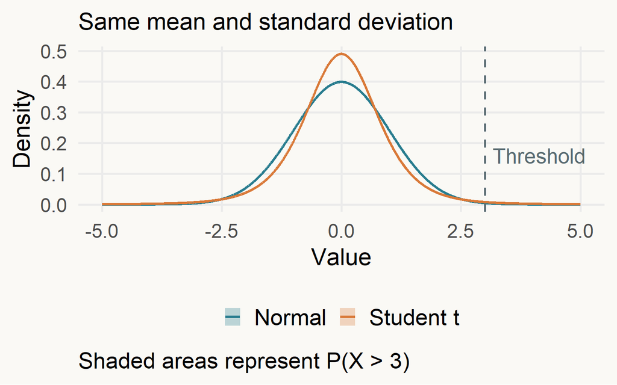

## A closer look at the right tail

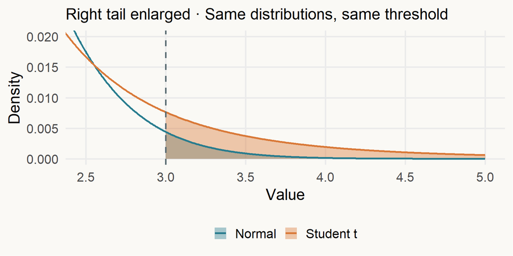

**Beyond 3 SD: Normal ≈ 0.135% · Student t ≈ 0.586%**

About **4×** as likely under t.

A similar-looking curve can give a very different tail probability.

## A distribution answers a question

**A quantitative variable:** a numerical quantity we measure or count.

**A probability distribution:** how probability is assigned to its possible values.

A distribution model describes **shape, center, and spread**, and helps us estimate **probabilities and percentiles**.

**For repair labor hours…**

What proportion of jobs require more than 8 hours?

What labor-hour threshold includes 90% of repair jobs?

## Is 94 mph fast?

**What are we measuring?**

Four-seam fastball release speed, in miles per hour (mph).

Typically a pitcher’s fastest pitch.

**Three MLB pitchers**

- Andrew Abbott · Cincinnati Reds
- Tanner Bibee · Cleveland Guardians
- Yoshinobu Yamamoto · Los Angeles Dodgers

**Why understand the distribution?**

- Establish a pitcher’s usual velocity range.
- Identify unusually fast or slow pitches.
- Track changes over time.
- Support coaching and training decisions.

## Does one distribution describe the whole season?

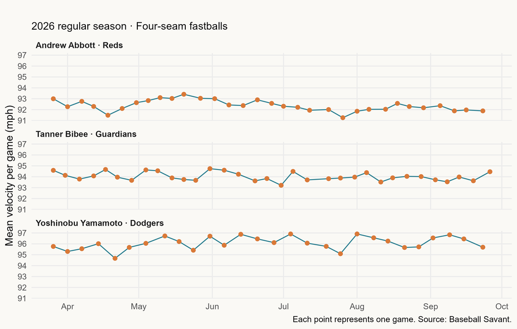

Pooling the season may hide changes over time.

## Three candidate models for each pitcher

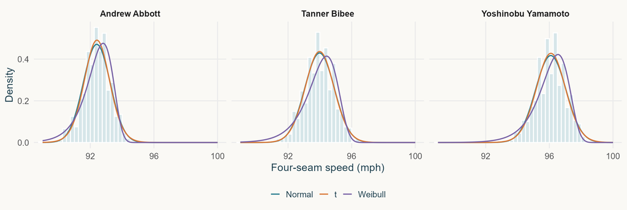

2026 regular-season four-seam fastballs. Normal, location-scale t, and two-parameter Weibull.

## What does the comparison say?

| Pitcher | Normal AIC | t AIC | Weibull AIC |
| --- | --- | --- | --- |
| Abbott | 3200.29 | 3197.22 | 3244.30 |
| Bibee | 1877.28 | 1878.81 | 1943.72 |
| Yamamoto | 1970.04 | 1970.49 | 1995.87 |

Compare AIC within a pitcher. Lower means better relative fit after a parameter penalty.

**Under our simplifying assumptions, AIC favors t for Abbott and Normal for Bibee and Yamamoto—but the Normal–t differences are small.**

**Lowest AIC among these candidates. Useful for our question?**

## A closer look at the quantiles

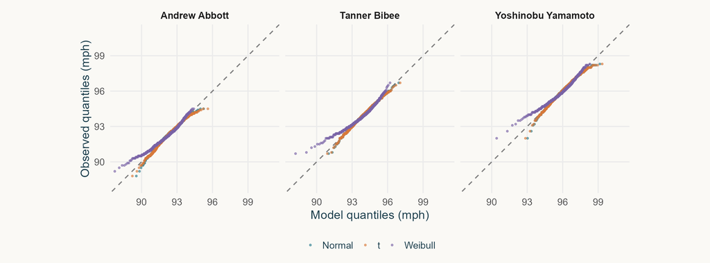

## A personal baseline changes the answer

| Pitcher | Observed share above 94 mph |
| --- | --- |
| Abbott | 1.65% |
| Bibee | 47.56% |
| Yamamoto | 97.62% |

An unusual pitch depends on the pitcher and the comparison period.

### What did we assume?

- We treat each pitcher’s velocity distribution as stable over the season.
- We treat individual pitches as independent observations.

**A good distributional fit does not establish independence or stability over time.**

## Cincinnati repair work

**How much mechanic labor does a repair require?**

**What are these records?**

- City of Cincinnati fleet maintenance and repair work orders.
- Our subset: **2,869 closed repair orders** for police equipment, work-order year **2022**.

**What do we measure?**

Recorded labor hours per repair order.

**Why understand the distribution?**

- Plan staffing and labor budgets.
- Estimate the proportion of labor-intensive jobs.
- Allow for unusually demanding repairs.

Labor hours measure work effort—not elapsed repair time or vehicle downtime.

Source: [Cincinnati Open Data · Fleet Preventative Maintenance & Repair Work Orders](https://data.cincinnati-oh.gov/Thriving-Neighborhoods/Fleet-Preventative-Maintenance-Repair-Work-Orders/2a8x-bxjm)

## Typical work and total work

**Median: 1.6 labor hours**

**Mean: 3.10 labor hours**

A few large jobs increase total labor demand.

32 orders record zero labor. Positive-labor models use the remaining 2,837 orders.

## Three models for positive labor

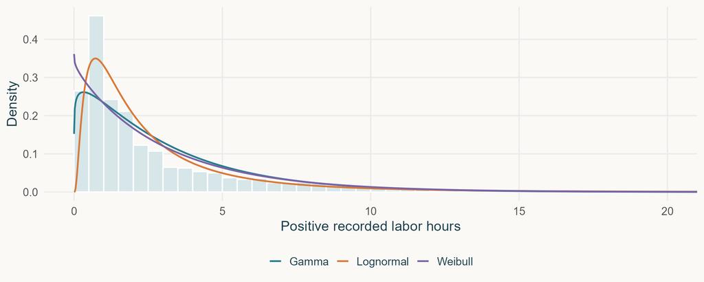

Models use all positive values. Display shows 0–20 hours, with the longer tail outside the view.

## Lognormal fits best among these candidates

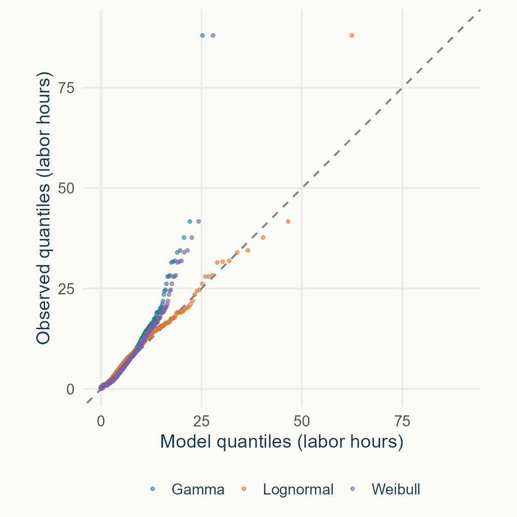

| Model | AIC |
| --- | --- |
| Gamma | 12147.59 |
| Lognormal | **11526.07** |
| Weibull | 12166.14 |

Lower AIC means better relative fit. Lognormal tracks the long tail most closely.

## Which model gets a large job right?

|  | Share above 8 hours | 90th percentile |
| --- | --- | --- |
| Observed | **8.81%** | **7.6 hours** |
| Gamma | 7.19% | 7.0 hours |
| Lognormal | 6.98% | 6.6 hours |
| Weibull | **7.96%** | **7.3 hours** |

Positive-labor orders (n = 2,837).

**Lognormal has the lowest AIC among these candidates; Weibull is closer to the observed values for these two questions.**

Underestimating large jobs can reduce planned capacity. Acceptable error depends on the decision.

## Flood claims after Hurricane Helene

**Where do these data come from?**

The **Federal Emergency Management Agency (FEMA)** manages the **National Flood Insurance Program (NFIP)**.

**Our sample**

- **781 flood insurance claims** associated with Hurricane Helene.
- North Carolina · 2024 losses · Single-family homes.
- Each policy has **$250,000 in building coverage**.

**What do we measure?**

Recorded building claim payments—not total flood damage.

Source: [OpenFEMA · NFIP Redacted Claims, Version 3](https://www.fema.gov/openfema-data-page/nfip-redacted-claims-v3)

Data snapshot: September 8, 2026 · Payments may change as claims develop.

## Why model insurance claim payments?

**An average payment does not tell us how often large claims occur.**

- How likely is a claim payment to exceed **$100,000**?
- How often do payments reach the **$250,000 coverage limit**?

**Underestimating large payments can lead to underestimating funding needs.**

## The policy helps shape the distribution

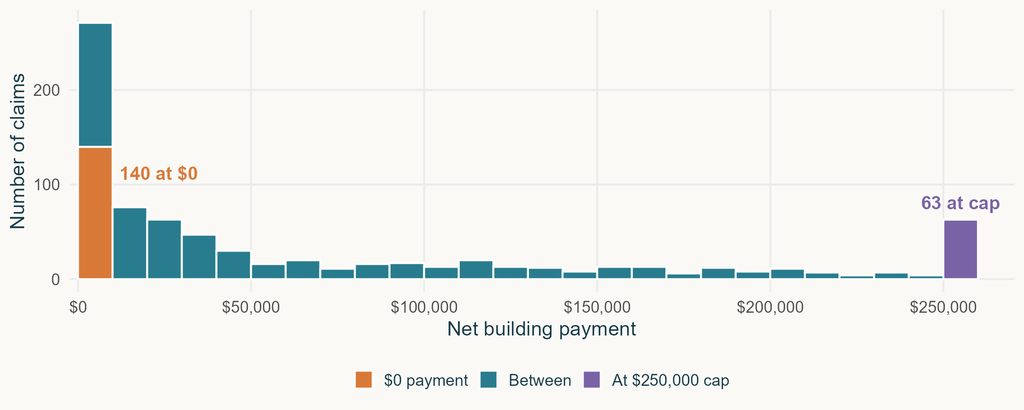

## A mixed distribution for payments

A point mass at **$0**: 17.93%

A continuous interior between $0 and $250,000: 74.01%

A point mass at **$250,000**: 8.07%

## One curve for the interior?

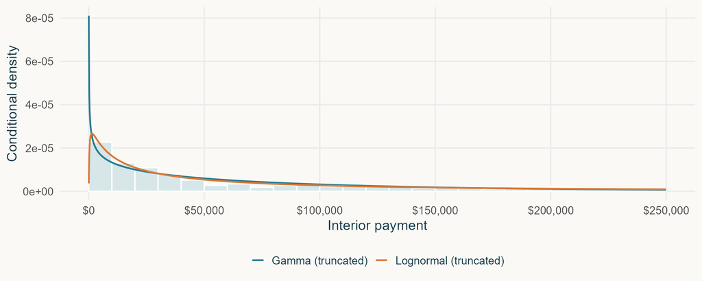

578 interior claims. Truncated Lognormal has lower AIC (ΔAIC ≈ 32.78).

**Payment above $100,000: observed 27.4% · model 25.5%**

Full model: point masses at $0 (17.93%) and $250,000 (8.07%), plus a truncated Lognormal interior (74.01%).

## Professor “Close Enough” revisited

Close enough for a typical value?

Close enough for a tail probability?

Close enough for the decision you need to make?

## You can make a presentation like this

This presentation uses **Quarto**.

A `.qmd` file combines Markdown, code, and presentation settings.

**MTH 209** introduces the skills behind reproducible statistical documents.

## All models are wrong, but some are useful

George Box

**Useful for what?**

## Thank You!

- Please do not hesitate to contact me (Tessa Chen) at ychen4@udayton.edu for questions or further discussions.

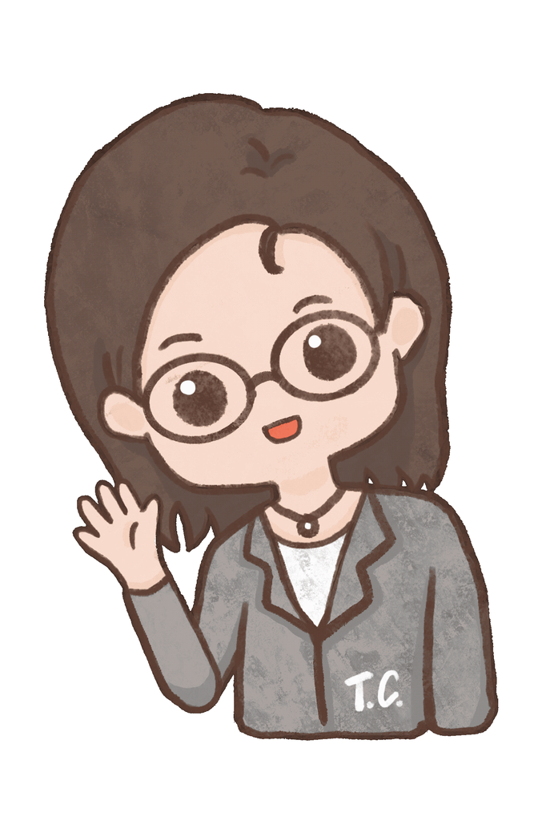